# excercise02

```python
import numpy as np
import pandas as pd
import matplotlib.pyplot as plt
import statsmodels.api as sm
import seaborn as sns
```

1. Load the auto.csv dataset again using the pandas.read function and remember to remove the missing values in the dataset, indicated by ‘?’, and then make sure the corresponding columns are casted to a numerical type.

```python
# Load the auto.csv dataset again using the pandas.read function
df = pd.read_csv('../data/auto/auto.csv')


# remove the missing values in the dataset, indicated by ‘?’
question_mark_mask = df.map(lambda x: x == '?')
question_mark_counts = question_mark_mask.sum()
print(question_mark_counts)

df = df[df['horsepower'] != '?']
```

```
mpg             0
cylinders       0
displacement    0
horsepower      6
weight          0
acceleration    0
model_year      0
origin          0
name            0
dtype: int64
```

```python
# make sure the corresponding columns are casted to a numerical type
columns_to_convert = ['mpg', 'cylinders', 'displacement', 'horsepower', 'weight', 'acceleration', 'model_year', 'origin']

df[columns_to_convert] = df[columns_to_convert].apply(pd.to_numeric)
df.dtypes
```

```
mpg             float64
cylinders         int64
displacement    float64
horsepower        int64
weight            int64
acceleration    float64
model_year        int64
origin            int64
name             object
dtype: object
```

```
                   mpg  cylinders  displacement  horsepower    weight  \
mpg           1.000000  -0.777618     -0.805127   -0.778427 -0.832244
cylinders    -0.777618   1.000000      0.950823    0.842983  0.897527
displacement -0.805127   0.950823      1.000000    0.897257  0.932994
horsepower   -0.778427   0.842983      0.897257    1.000000  0.864538
weight       -0.832244   0.897527      0.932994    0.864538  1.000000
acceleration  0.423329  -0.504683     -0.543800   -0.689196 -0.416839
model_year    0.580541  -0.345647     -0.369855   -0.416361 -0.309120
origin        0.565209  -0.568932     -0.614535   -0.455171 -0.585005

              acceleration  model_year    origin
mpg               0.423329    0.580541  0.565209
cylinders        -0.504683   -0.345647 -0.568932
displacement     -0.543800   -0.369855 -0.614535
horsepower       -0.689196   -0.416361 -0.455171
weight           -0.416839   -0.309120 -0.585005
acceleration      1.000000    0.290316  0.212746
model_year        0.290316    1.000000  0.181528
origin            0.212746    0.181528  1.000000
```

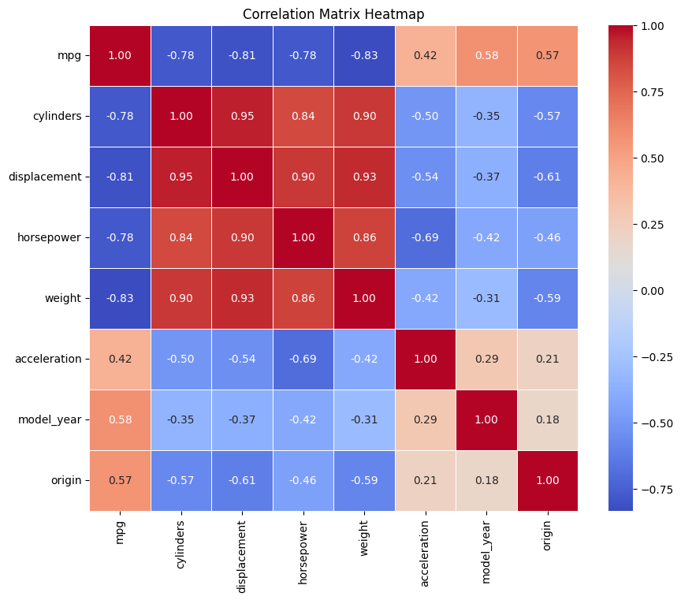

```python
# CORRELATION MATRIX
corr_matrix = df.drop('name', axis=1).corr()
print(corr_matrix)
# Plot the correlation matrix
plt.figure(figsize=(10, 8))
sns.heatmap(corr_matrix, annot=True, fmt=".2f", cmap='coolwarm', linewidths=0.5)
plt.title('Correlation Matrix Heatmap')
plt.show()
```

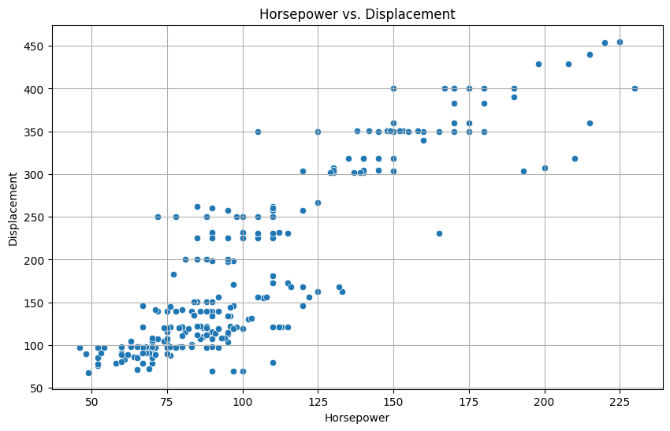

```python
# Plot horsepower vs. displacement
plt.figure(figsize=(10, 6))
sns.scatterplot(x='horsepower', y='displacement', data=df)
plt.xlabel('Horsepower')
plt.ylabel('Displacement')
plt.title('Horsepower vs. Displacement')
plt.grid(True)
plt.show()
```

2. a. Inspect the data. b. Plot the relationships between the different variables and mpg. - Use for example the matplotlib.pyplot scatter plot. - Do you already suspect what features might be helpful to regress the consumption? c. Save the graph.

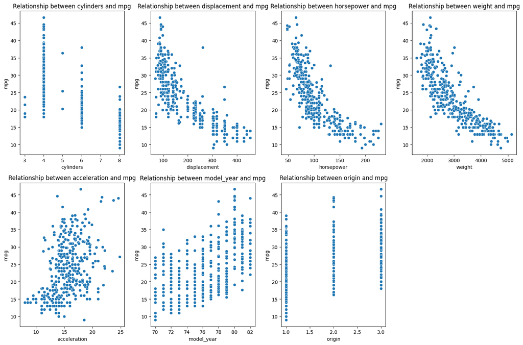

```python
variables = ['cylinders', 'displacement', 'horsepower', 'weight', 'acceleration', 'model_year', 'origin']

plt.figure(figsize=(15, 10))

for i, var in enumerate(variables, 1):
    plt.subplot(2, 4, i)
    sns.scatterplot(x=var, y='mpg', data=df)
    plt.title(f'Relationship between {var} and mpg')
    plt.xlabel(var)
    plt.ylabel('mpg')

plt.tight_layout()
plt.savefig('relationships_with_mpg.png')
plt.show()
```

# Notes

Logistic transformation?

3. Perform a linear regression using the OLS function from the statsmodels package. Use 'horsepower' as feature and regress the value 'mpg'. It is a good idea to look up the statsmodels documentation on OLS, to understand how to use it. Further, plot the results including your regression line.

```
                            OLS Regression Results
==============================================================================
Dep. Variable:                    mpg   R-squared:                       0.606
Model:                            OLS   Adj. R-squared:                  0.605
Method:                 Least Squares   F-statistic:                     599.7
Date:                Wed, 07 Aug 2024   Prob (F-statistic):           7.03e-81
Time:                        11:21:17   Log-Likelihood:                -1178.7
No. Observations:                 392   AIC:                             2361.
Df Residuals:                     390   BIC:                             2369.
Df Model:                           1
Covariance Type:            nonrobust
==============================================================================
                 coef    std err          t      P>|t|      [0.025      0.975]
------------------------------------------------------------------------------
const         39.9359      0.717     55.660      0.000      38.525      41.347
horsepower    -0.1578      0.006    -24.489      0.000      -0.171      -0.145
==============================================================================
Omnibus:                       16.432   Durbin-Watson:                   0.920
Prob(Omnibus):                  0.000   Jarque-Bera (JB):               17.305
Skew:                           0.492   Prob(JB):                     0.000175
Kurtosis:                       3.299   Cond. No.                         322.
==============================================================================

Notes:
[1] Standard Errors assume that the covariance matrix of the errors is correctly specified.
```

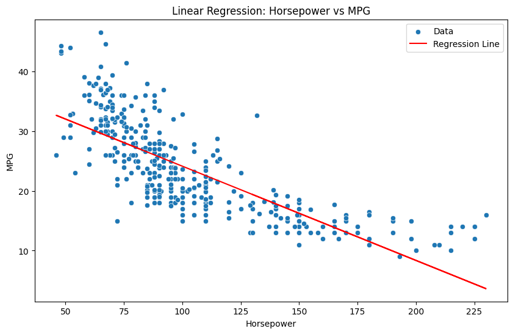

```python
# Step 4: Perform linear regression using OLS
X = df['horsepower']
y = df['mpg']
X = sm.add_constant(X)  # Adds a constant term to the predictor

model = sm.OLS(y, X).fit()
predictions = model.predict(X)

# Print out the statistics
print(model.summary())

# Step 5: Plot the results including the regression line
plt.figure(figsize=(10, 6))
sns.scatterplot(x='horsepower', y='mpg', data=df, label='Data')
plt.plot(df['horsepower'], predictions, color='red', label='Regression Line')
plt.xlabel('Horsepower')
plt.ylabel('MPG')
plt.title('Linear Regression: Horsepower vs MPG')
plt.legend()
plt.savefig('linear_regression_horsepower_mpg.png')
plt.show()
```

4. Now extend the model using all features. How would you determine which features are important and which aren't? Try to find a good selection of features for your model.

```
                            OLS Regression Results
==============================================================================
Dep. Variable:                    mpg   R-squared:                       0.821
Model:                            OLS   Adj. R-squared:                  0.818
Method:                 Least Squares   F-statistic:                     252.4
Date:                Wed, 07 Aug 2024   Prob (F-statistic):          2.04e-139
Time:                        11:21:18   Log-Likelihood:                -1023.5
No. Observations:                 392   AIC:                             2063.
Df Residuals:                     384   BIC:                             2095.
Df Model:                           7
Covariance Type:            nonrobust
================================================================================
                   coef    std err          t      P>|t|      [0.025      0.975]
--------------------------------------------------------------------------------
const          -17.2184      4.644     -3.707      0.000     -26.350      -8.087
cylinders       -0.4934      0.323     -1.526      0.128      -1.129       0.142
displacement     0.0199      0.008      2.647      0.008       0.005       0.035
horsepower      -0.0170      0.014     -1.230      0.220      -0.044       0.010
weight          -0.0065      0.001     -9.929      0.000      -0.008      -0.005
acceleration     0.0806      0.099      0.815      0.415      -0.114       0.275
model_year       0.7508      0.051     14.729      0.000       0.651       0.851
origin           1.4261      0.278      5.127      0.000       0.879       1.973
==============================================================================
Omnibus:                       31.906   Durbin-Watson:                   1.309
Prob(Omnibus):                  0.000   Jarque-Bera (JB):               53.100
Skew:                           0.529   Prob(JB):                     2.95e-12
Kurtosis:                       4.460   Cond. No.                     8.59e+04
==============================================================================

Notes:
[1] Standard Errors assume that the covariance matrix of the errors is correctly specified.
[2] The condition number is large, 8.59e+04. This might indicate that there are
strong multicollinearity or other numerical problems.
```

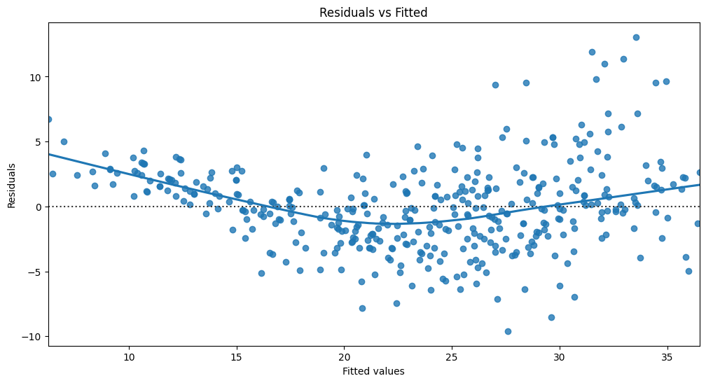

```python
# Handle the 'name' column
df_ = df.drop('name', axis=1)

# Step 3: Prepare the data for regression
X = df_.drop('mpg', axis=1)
y = df_['mpg']
X = sm.add_constant(X)  # Adds a constant term to the predictor

# Step 4: Perform the regression using OLS
model = sm.OLS(y, X).fit()
predictions = model.predict(X)

# Print out the statistics
print(model.summary())

# Step 5: Evaluate the model and feature importance
# - Check the p-values of the features
# - Use statistical tests and methods like AIC, BIC for model selection

# Optionally, visualize some residual plots
plt.figure(figsize=(12, 6))
sns.residplot(x=predictions, y=model.resid, lowess=True)
plt.xlabel('Fitted values')
plt.ylabel('Residuals')
plt.title('Residuals vs Fitted')
plt.show()
```

# Feature selection

```
                            OLS Regression Results
==============================================================================
Dep. Variable:                    mpg   R-squared:                       0.817
Model:                            OLS   Adj. R-squared:                  0.816
Method:                 Least Squares   F-statistic:                     579.2
Date:                Wed, 07 Aug 2024   Prob (F-statistic):          7.26e-143
Time:                        12:36:05   Log-Likelihood:                -1027.8
No. Observations:                 392   AIC:                             2064.
Df Residuals:                     388   BIC:                             2080.
Df Model:                           3
Covariance Type:            nonrobust
==============================================================================
                 coef    std err          t      P>|t|      [0.025      0.975]
------------------------------------------------------------------------------
const        -18.0459      4.001     -4.510      0.000     -25.913     -10.179
weight        -0.0060      0.000    -23.588      0.000      -0.006      -0.005
model_year     0.7571      0.048     15.668      0.000       0.662       0.852
origin         1.1504      0.259      4.439      0.000       0.641       1.660
==============================================================================
Omnibus:                       39.172   Durbin-Watson:                   1.275
Prob(Omnibus):                  0.000   Jarque-Bera (JB):               76.003
Skew:                           0.577   Prob(JB):                     3.13e-17
Kurtosis:                       4.823   Cond. No.                     7.33e+04
==============================================================================

Notes:
[1] Standard Errors assume that the covariance matrix of the errors is correctly specified.
[2] The condition number is large, 7.33e+04. This might indicate that there are
strong multicollinearity or other numerical problems.
```

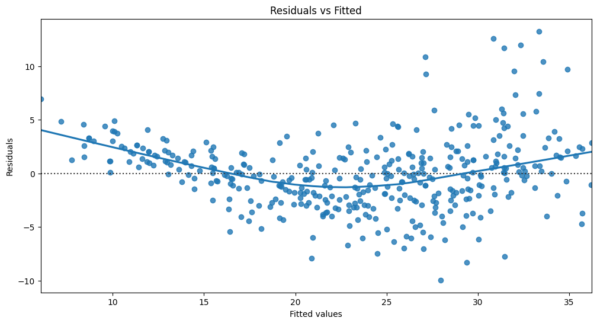

```python
# Handle the 'name' column
df_ = df.drop('name', axis=1)

# DROP FEATURES
df_ = df_.drop('cylinders', axis=1)
df_ = df_.drop('horsepower', axis=1)
df_ = df_.drop('acceleration', axis=1)
df_ = df_.drop('displacement', axis=1)





# Step 3: Prepare the data for regression
X = df_.drop('mpg', axis=1)
y = df_['mpg']
X = sm.add_constant(X)  # Adds a constant term to the predictor

# Step 4: Perform the regression using OLS
model = sm.OLS(y, X).fit()
predictions = model.predict(X)

# Print out the statistics
print(model.summary())

# Step 5: Evaluate the model and feature importance
# - Check the p-values of the features
# - Use statistical tests and methods like AIC, BIC for model selection

# Optionally, visualize some residual plots
plt.figure(figsize=(12, 6))
sns.residplot(x=predictions, y=model.resid, lowess=True)
plt.xlabel('Fitted values')
plt.ylabel('Residuals')
plt.title('Residuals vs Fitted')
plt.show()
```

5. Can you improve your regression performance by trying different transformations of the variables, such as log(𝑋), √𝑋, 1/𝑋, 𝑋^2 and so on. For each transformation, which features are important and which aren’t?

```python
# Handle the 'name' column
df_ = df.drop('name', axis=1)

# Prepare the target variable
y = df_['mpg']

# Apply different transformations
transformations = {
    'log': np.log,
    'sqrt': np.sqrt,
    'reciprocal': lambda x: 1 / x,
    'square': np.square
}

# Function to perform OLS regression and return summary
def perform_ols(X, y):
    X = sm.add_constant(X)
    model = sm.OLS(y, X).fit()
    return model

# Store results for each transformation
results = {}

# Original model without transformation
X = df_.drop('mpg', axis=1)
original_model = perform_ols(X, y)
results['original'] = original_model


# Apply transformations and perform regression
for name, func in transformations.items():
    X_transformed = df_.drop('mpg', axis=1).apply(func)
    model = perform_ols(X_transformed, y)
    results[name] = model


# Compare results
for name, model in results.items():
    print(f"\nModel with {name if name != 'original' else 'no'} transformation")
    print(model.summary())
```

```
Model with no transformation
                            OLS Regression Results
==============================================================================
Dep. Variable:                    mpg   R-squared:                       0.821
Model:                            OLS   Adj. R-squared:                  0.818
Method:                 Least Squares   F-statistic:                     252.4
Date:                Wed, 07 Aug 2024   Prob (F-statistic):          2.04e-139
Time:                        11:45:07   Log-Likelihood:                -1023.5
No. Observations:                 392   AIC:                             2063.
Df Residuals:                     384   BIC:                             2095.
Df Model:                           7
Covariance Type:            nonrobust
================================================================================
                   coef    std err          t      P>|t|      [0.025      0.975]
--------------------------------------------------------------------------------
const          -17.2184      4.644     -3.707      0.000     -26.350      -8.087
cylinders       -0.4934      0.323     -1.526      0.128      -1.129       0.142
displacement     0.0199      0.008      2.647      0.008       0.005       0.035
horsepower      -0.0170      0.014     -1.230      0.220      -0.044       0.010
weight          -0.0065      0.001     -9.929      0.000      -0.008      -0.005
acceleration     0.0806      0.099      0.815      0.415      -0.114       0.275
model_year       0.7508      0.051     14.729      0.000       0.651       0.851
origin           1.4261      0.278      5.127      0.000       0.879       1.973
==============================================================================
Omnibus:                       31.906   Durbin-Watson:                   1.309
Prob(Omnibus):                  0.000   Jarque-Bera (JB):               53.100
Skew:                           0.529   Prob(JB):                     2.95e-12
Kurtosis:                       4.460   Cond. No.                     8.59e+04
==============================================================================

Notes:
[1] Standard Errors assume that the covariance matrix of the errors is correctly specified.
[2] The condition number is large, 8.59e+04. This might indicate that there are
strong multicollinearity or other numerical problems.

Model with log transformation
                            OLS Regression Results
==============================================================================
Dep. Variable:                    mpg   R-squared:                       0.848
Model:                            OLS   Adj. R-squared:                  0.845
```

[output cut: 119 more lines]

```
weight       -9.351e-07   8.98e-08    -10.416      0.000   -1.11e-06   -7.59e-07
acceleration     0.0063      0.003      2.334      0.020       0.001       0.012
model_year       0.0050      0.000     14.160      0.000       0.004       0.006
origin           0.4129      0.069      5.971      0.000       0.277       0.549
==============================================================================
Omnibus:                       21.204   Durbin-Watson:                   1.316
Prob(Omnibus):                  0.000   Jarque-Bera (JB):               29.337
Skew:                           0.431   Prob(JB):                     4.26e-07
Kurtosis:                       4.027   Cond. No.                     1.45e+08
==============================================================================

Notes:
[1] Standard Errors assume that the covariance matrix of the errors is correctly specified.
[2] The condition number is large, 1.45e+08. This might indicate that there are
strong multicollinearity or other numerical problems.
```

```
                            OLS Regression Results
==============================================================================
Dep. Variable:                    mpg   R-squared:                       0.880
Model:                            OLS   Adj. R-squared:                  0.877
Method:                 Least Squares   F-statistic:                     400.4
Date:                Wed, 07 Aug 2024   Prob (F-statistic):          3.98e-172
Time:                        13:03:12   Log-Likelihood:                 281.90
No. Observations:                 392   AIC:                            -547.8
Df Residuals:                     384   BIC:                            -516.0
Df Model:                           7
Covariance Type:            nonrobust
================================================================================
                   coef    std err          t      P>|t|      [0.025      0.975]
--------------------------------------------------------------------------------
const            1.7509      0.166     10.533      0.000       1.424       2.078
cylinders       -0.0279      0.012     -2.415      0.016      -0.051      -0.005
displacement     0.0006      0.000      2.365      0.019       0.000       0.001
horsepower      -0.0015      0.000     -2.989      0.003      -0.002      -0.001
weight          -0.0003   2.33e-05    -10.931      0.000      -0.000      -0.000
acceleration    -0.0013      0.004     -0.381      0.703      -0.008       0.006
model_year       0.0296      0.002     16.211      0.000       0.026       0.033
origin           0.0407      0.010      4.089      0.000       0.021       0.060
==============================================================================
Omnibus:                        7.884   Durbin-Watson:                   1.397
Prob(Omnibus):                  0.019   Jarque-Bera (JB):               10.954
Skew:                          -0.148   Prob(JB):                      0.00418
Kurtosis:                       3.763   Cond. No.                     8.59e+04
==============================================================================

Notes:
[1] Standard Errors assume that the covariance matrix of the errors is correctly specified.
[2] The condition number is large, 8.59e+04. This might indicate that there are
strong multicollinearity or other numerical problems.
```

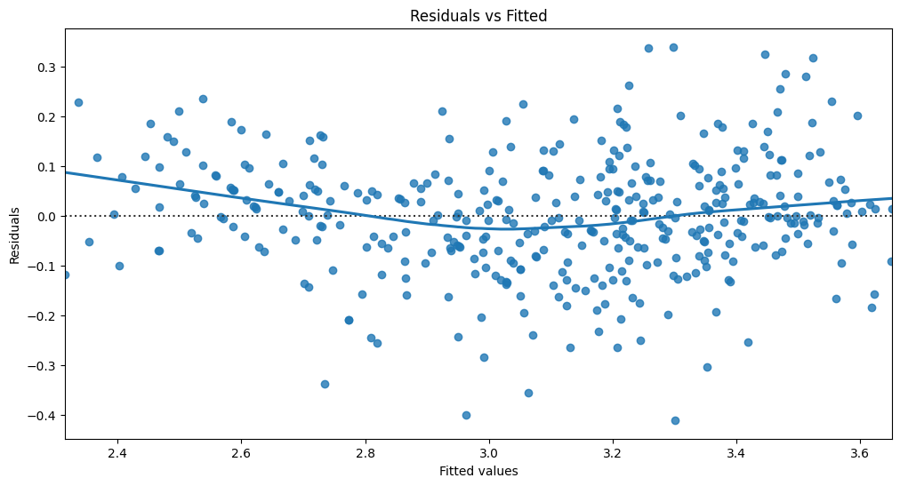

```
                            OLS Regression Results
==============================================================================
Dep. Variable:                    mpg   R-squared:                       0.856
Model:                            OLS   Adj. R-squared:                  0.853
Method:                 Least Squares   F-statistic:                     326.3
Date:                Wed, 07 Aug 2024   Prob (F-statistic):          2.41e-157
Time:                        13:03:12   Log-Likelihood:                -89.790
No. Observations:                 392   AIC:                             195.6
Df Residuals:                     384   BIC:                             227.4
Df Model:                           7
Covariance Type:            nonrobust
================================================================================
                   coef    std err          t      P>|t|      [0.025      0.975]
--------------------------------------------------------------------------------
const            1.0753      0.429      2.506      0.013       0.232       1.919
cylinders       -0.0594      0.030     -1.990      0.047      -0.118      -0.001
displacement     0.0018      0.001      2.524      0.012       0.000       0.003
horsepower      -0.0025      0.001     -1.972      0.049      -0.005   -7.68e-06
weight          -0.0006   6.02e-05    -10.570      0.000      -0.001      -0.001
acceleration     0.0027      0.009      0.300      0.764      -0.015       0.021
model_year       0.0738      0.005     15.675      0.000       0.065       0.083
origin           0.1217      0.026      4.735      0.000       0.071       0.172
==============================================================================
Omnibus:                        9.733   Durbin-Watson:                   1.343
Prob(Omnibus):                  0.008   Jarque-Bera (JB):               14.701
Skew:                           0.164   Prob(JB):                     0.000642
Kurtosis:                       3.890   Cond. No.                     8.59e+04
==============================================================================

Notes:
[1] Standard Errors assume that the covariance matrix of the errors is correctly specified.
[2] The condition number is large, 8.59e+04. This might indicate that there are
strong multicollinearity or other numerical problems.
```

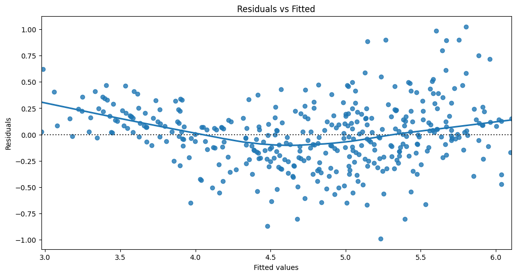

```
                            OLS Regression Results
==============================================================================
Dep. Variable:                    mpg   R-squared:                       0.885
Model:                            OLS   Adj. R-squared:                  0.883
Method:                 Least Squares   F-statistic:                     423.2
Date:                Wed, 07 Aug 2024   Prob (F-statistic):          3.45e-176
Time:                        13:03:12   Log-Likelihood:                 1474.2
No. Observations:                 392   AIC:                            -2932.
Df Residuals:                     384   BIC:                            -2901.
Df Model:                           7
Covariance Type:            nonrobust
================================================================================
                   coef    std err          t      P>|t|      [0.025      0.975]
--------------------------------------------------------------------------------
const            0.0914      0.008     11.518      0.000       0.076       0.107
cylinders        0.0015      0.001      2.729      0.007       0.000       0.003
displacement  -2.57e-05   1.28e-05     -2.001      0.046    -5.1e-05   -4.42e-07
horsepower       0.0001   2.36e-05      5.326      0.000    7.92e-05       0.000
weight        1.086e-05   1.11e-06      9.748      0.000    8.67e-06    1.31e-05
acceleration     0.0003      0.000      2.025      0.044    9.96e-06       0.001
model_year      -0.0013   8.71e-05    -14.510      0.000      -0.001      -0.001
origin          -0.0010      0.000     -2.129      0.034      -0.002   -7.72e-05
==============================================================================
Omnibus:                       48.908   Durbin-Watson:                   1.478
Prob(Omnibus):                  0.000   Jarque-Bera (JB):              103.889
Skew:                           0.673   Prob(JB):                     2.76e-23
Kurtosis:                       5.133   Cond. No.                     8.59e+04
==============================================================================

Notes:
[1] Standard Errors assume that the covariance matrix of the errors is correctly specified.
[2] The condition number is large, 8.59e+04. This might indicate that there are
strong multicollinearity or other numerical problems.
```

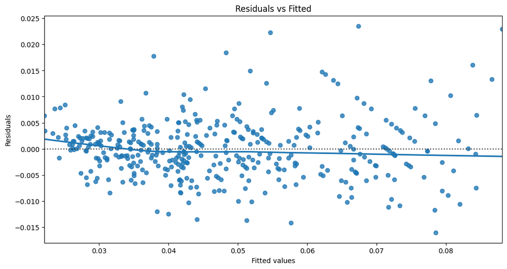

```
                            OLS Regression Results
==============================================================================
Dep. Variable:                    mpg   R-squared:                       0.729
Model:                            OLS   Adj. R-squared:                  0.724
Method:                 Least Squares   F-statistic:                     147.8
Date:                Wed, 07 Aug 2024   Prob (F-statistic):          8.13e-105
Time:                        13:03:12   Log-Likelihood:                -2647.9
No. Observations:                 392   AIC:                             5312.
Df Residuals:                     384   BIC:                             5344.
Df Model:                           7
Covariance Type:            nonrobust
================================================================================
                   coef    std err          t      P>|t|      [0.025      0.975]
--------------------------------------------------------------------------------
const        -1877.7041    292.836     -6.412      0.000   -2453.467   -1301.941
cylinders      -14.3596     20.384     -0.704      0.482     -54.438      25.718
displacement     1.3277      0.474      2.802      0.005       0.396       2.259
horsepower      -0.3587      0.869     -0.413      0.680      -2.068       1.350
weight          -0.3522      0.041     -8.567      0.000      -0.433      -0.271
acceleration     9.2779      6.232      1.489      0.137      -2.976      21.532
model_year      40.8099      3.214     12.698      0.000      34.491      47.129
origin          95.0940     17.537      5.422      0.000      60.613     129.575
==============================================================================
Omnibus:                      109.844   Durbin-Watson:                   1.302
Prob(Omnibus):                  0.000   Jarque-Bera (JB):              337.847
Skew:                           1.278   Prob(JB):                     4.34e-74
Kurtosis:                       6.762   Cond. No.                     8.59e+04
==============================================================================

Notes:
[1] Standard Errors assume that the covariance matrix of the errors is correctly specified.
[2] The condition number is large, 8.59e+04. This might indicate that there are
strong multicollinearity or other numerical problems.
```

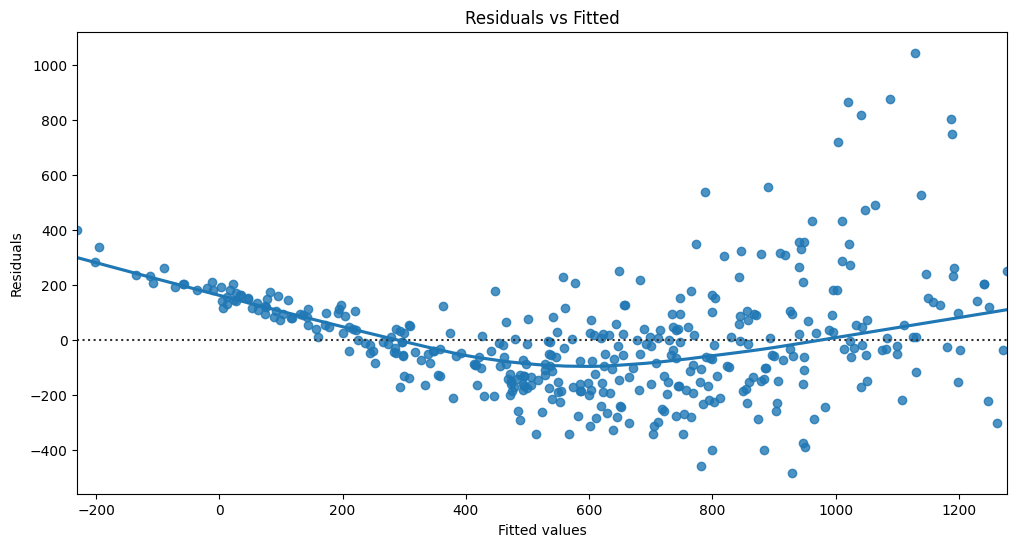

```python
# Handle the 'name' column
df_ = df.drop('name', axis=1)

# DROP FEATURES
# df_ = df_.drop('cylinders', axis=1)
# df_ = df_.drop('horsepower', axis=1)
# df_ = df_.drop('acceleration', axis=1)
# df_ = df_.drop('displacement', axis=1)


transformations = {
    'log': np.log,
    'sqrt': np.sqrt,
    'reciprocal': lambda x: 1 / x,
    'square': np.square
}

for transformation in transformations:
    # Step 3: Prepare the data for regression
    X = df_.drop('mpg', axis=1)
    y = df_['mpg'].apply(transformations[transformation])
    X = sm.add_constant(X)  # Adds a constant term to the predictor

    # Step 4: Perform the regression using OLS
    model = sm.OLS(y, X).fit()
    predictions = model.predict(X)

    # Print out the statistics
    print(model.summary())

    # Step 5: Evaluate the model and feature importance
    # - Check the p-values of the features
    # - Use statistical tests and methods like AIC, BIC for model selection

    # Optionally, visualize some residual plots
    plt.figure(figsize=(12, 6))
    sns.residplot(x=predictions, y=model.resid, lowess=True)
    plt.xlabel('Fitted values')
    plt.ylabel('Residuals')
    plt.title('Residuals vs Fitted')
    plt.show()
```